# Brain-Computer Interface Data Classification

1. Introduction
2. Data Exploration & Preprcessing
   1. Import Data
   2. Visualize Data Using MNE
3. Models Definition
   1. EEGNET
   2. Recursive EEGNET
   3. Adversarial Data Augmentation
4. Model Selection
   1. UTIL Functions
   2. Hyper-parameter Optimization (Optuna)
   3. Validation Accuracy
5. Unachieved Experiments
6. Conclusion

# Introduction

In this challenge, we will treat electroencephalogram data and try to predict if a fixation is used for control or if it is a spontaneous one.

This can be applied to detect the user's intention to make an action by analyzing the brain signals, and automatically perfom this action, which can help him or her to focus on the main activity rather than on the motor task (mouse or keyboard manipulations).

The EEG data was recorded at $500Hz$ sampling rate for $13$ different participents using $19$ electrodes.

The $19$ electrodes to be used are placed in different positions of the brain. Their positions are given by polar cordinates and shown in the next table. We need to convert polar cordinate to xy cordinates to be able to represent them later.

```python
import pandas as pd
import numpy as np
import mne
import tensorflow
import os

import matplotlib.pyplot as plt
from matplotlib.animation import FuncAnimation
from matplotlib import rc
import matplotlib

from IPython.display import HTML

from data import DataBuildClassifier

rc('animation', html='html5')
```

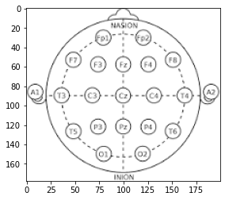

```python
plt.imshow(im)
```

```python
df = pd.read_csv('eeg/order_locations.info', sep='\t', header=None, names=['channel_id', 'ang', 'dist', 'channel_name'], skiprows=1)
df
```

|  | channel_id | ang | dist | channel_name |
| --- | --- | --- | --- | --- |
| 0 | 1 | 0 | 0.25556 | Fz |
| 1 | 2 | -39 | 0.33333 | F3 |
| 2 | 3 | 39 | 0.33333 | F4 |
| 3 | 4 | 90 | 0.00000 | Cz |
| 4 | 5 | -90 | 0.25556 | C3 |
| 5 | 6 | 90 | 0.25556 | C4 |
| 6 | 7 | 180 | 0.25556 | Pz |
| 7 | 8 | -158 | 0.27778 | P1 |
| 8 | 9 | 158 | 0.27778 | P2 |
| 9 | 10 | -141 | 0.33333 | P3 |
| 10 | 11 | 141 | 0.33333 | P4 |
| 11 | 12 | 180 | 0.38333 | POz |
| 12 | 13 | -157 | 0.41111 | PO3 |
| 13 | 14 | 157 | 0.41111 | PO4 |
| 14 | 15 | -144 | 0.51111 | PO7 |
| 15 | 16 | 144 | 0.51111 | PO8 |
| 16 | 17 | 180 | 0.51111 | Oz |
| 17 | 18 | -162 | 0.51111 | O1 |
| 18 | 19 | 162 | 0.51111 | O2 |

```python
def polar2z(r,theta):
    return r * np.exp( 1j * (- theta + 90) * np.pi / 180 )

rs = df[['dist']].values
thetas = df[['ang']].values

xs, ys = polar2z(rs, thetas).real, polar2z(rs, thetas).imag
xycords = np.concatenate((xs, ys), axis=1)
```

# Data Exploration & Preprocessing

## Import Data

```python
data_loader = DataBuildClassifier('eeg/') #Path to directory with data (i.e NewData contatins 25/, 26/ ....)
all_subjects = [25,26,27,28,29,30,32,33,34,35,36,37,38]
subjects = data_loader.get_data(all_subjects,
                                shuffle=False,
                                windows=[(0.2,0.5)],
                                baseline_window=(0.2,0.3),
                                resample_to=500)
print("Participants:", list(subjects.keys()))
X, y = subjects[25]
print(X.shape) #EEG epochs (Trials) x Time x Channels
print(y.shape)
```

```
Participants: [25, 26, 27, 28, 29, 30, 32, 33, 34, 35, 36, 37, 38]
(329, 150, 19)
(329,)
```

We used the code provided by LIKANblk at https://github.com/LIKANblk/ebci_data_loader/blob/master/data.py to load the data. Data is stored in a dictionary where keys are the participants' IDs and the values are tuples of feature matrices and label vectors.

Each participant has a different number of trials (between $329$ and $668$). So our EEG data is matrices of shape $[N, 150, 19]$ where $N$ is the number of trials for each participant.

At this stage, we used a resampling value of $500Hz$ which gives $150$ data points for each trial since the length is $0.3s$. Later, we will tune the resampling parameter so the dimensions of input data will also vary.

## Visualize Data Using MNE

The MNE library is a god tool that allows exploring and visualizing EEG data. As a first step, we choose to plot the amplitude topography of our data within different types of fixations (controlling vs non-controlling). These estimation were obtaining by averaging EEG data over all trials (grouped by label) for a random participant which could give us a global idea about the negativity topography over time using the animation. To comare different participants, we also performed an average over the $0.3s$ interval for each participant.

First, we can clearly see the different between controlling and non-controlling responses in the animation. In fact, negativity level represented in blue was important and remained until the end for the controlling response.

Despite responding to the same tasks, participants had very different reactions represented in the figures below, which makes us thing about creating a different classification model for each participant.

```python
ind_0 = np.where(y == 0)[0]
ind_1 = np.where(y == 1)[0]

X_0 = X[ind_0]
X_1 = X[ind_1]

X_0_mean = np.mean(X_0, axis=0)
X_1_mean = np.mean(X_1, axis=0)

def animation_frame(i):
    ax0.clear()
    ax1.clear()
    im0, cn0 = mne.viz.plot_topomap(data = X_0_mean[i], pos=xycords, sphere=0.6, axes=ax0);
    im1, cn1 = mne.viz.plot_topomap(data = X_1_mean[i], pos=xycords, sphere=0.6, axes=ax1)
    ax0.set_xlabel('Non-controlling')
    ax1.set_xlabel('Controlling')
    return cn0, cn1
```

```python
fig, (ax0, ax1) = plt.subplots(1,2);
anim = FuncAnimation(fig, func=animation_frame, frames=150, interval=50);
html = anim.to_html5_video();
HTML(html)
```

[video not shown]

```python
matplotlib.use('Qt5Agg')
```

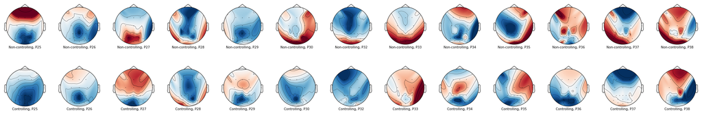

```python
fig, axes = plt.subplots(2,13, figsize=(39, 6));

for i, key in enumerate(subjects):
    X, y = subjects[key]
    ind_0 = np.where(y == 0)[0]
    ind_1 = np.where(y == 1)[0]

    X_0 = X[ind_0]
    X_1 = X[ind_1]

    # the mean over all epoches
    X_0_mean_ep = np.mean(X_0, axis=0)
    X_1_mean_ep = np.mean(X_1, axis=0)

    X_0_mean_time = np.mean(X_0_mean_ep, axis=0)
    X_1_mean_time = np.mean(X_1_mean_ep, axis=0)

    mne.viz.plot_topomap(data = X_0_mean_time, pos=xycords, sphere=0.6, axes=axes[0,i])
    mne.viz.plot_topomap(data = X_1_mean_time, pos=xycords, sphere=0.6, axes=axes[1,i])

    axes[0,i].set_xlabel('Non-controlling, P' + str(key))
    axes[1,i].set_xlabel('Controlling, P' + str(key))
```